# Bases de Datos relacionales

## Introducción

Iniciemos creando una conexión al archivo SQL

```r
mydb <- dbConnect(RSQLite::SQLite(), "my-db.sqlite")
```

```r
dbListTables(mydb)
```

```
[1] "company_mast"   "customer"       "emp_department" "emp_details"
[5] "item_mast"      "orders"         "salesman"
```

```r
dbListFields(mydb, "salesman")
```

```
[1] "salesman_id" "name"        "city"        "commission"
```

Ejecutamos la primer consulta

```r
dbGetQuery(mydb, 'SELECT * FROM salesman')
```

| salesman_id | name | city | commission |
| --- | --- | --- | --- |
| 5001 | James Hoog | New York | 0.15 |
| 5002 | Nail Knite | Paris | 0.13 |
| 5005 | Pit Alex | London | 0.11 |
| 5006 | Mc Lyon | Paris | 0.14 |
| 5007 | Paul Adam | Rome | 0.13 |
| 5003 | Lauson Hen | San Jose | 0.12 |

```r
dbGetQuery(mydb, 'SELECT * FROM customer')
```

| customer_id | cust_name | city | grade | salesman_id |
| --- | --- | --- | --- | --- |
| 3002 | Nick Rimando | New York | 100 | 5001 |
| 3007 | Brad Davis | New York | 200 | 5001 |
| 3005 | Graham Zusi | California | 200 | 5002 |
| 3008 | Julian Green | London | 300 | 5002 |
| 3004 | Fabian Johnson | Paris | 300 | 5006 |
| 3009 | Geoff Cameron | Berlin | 100 | 5003 |
| 3003 | Jozy Altidor | Moscow | 200 | 5007 |
| 3001 | Brad Guzan | London | NA | 5005 |

```r
dbGetQuery(mydb, 'SELECT * FROM orders')
```

| ord_no | purch_amt | ord_date | customer_id | salesman_id |
| --- | --- | --- | --- | --- |
| 70001 | 150.50 | 1349395200 | 3005 | 5002 |
| 70009 | 270.65 | 1347235200 | 3001 | 5005 |
| 70002 | 65.26 | 1349395200 | 3002 | 5001 |
| 70004 | 110.50 | 1345161600 | 3009 | 5003 |
| 70007 | 948.50 | 1347235200 | 3005 | 5002 |
| 70005 | 2400.60 | 1343347200 | 3007 | 5001 |
| 70008 | 5760.00 | 1347235200 | 3002 | 5001 |
| 70010 | 1983.43 | 1349827200 | 3004 | 5006 |
| 70003 | 2480.40 | 1349827200 | 3009 | 5003 |
| 70012 | 250.45 | 1340755200 | 3008 | 5002 |

[output cut: 2 more lines]

```r
dbGetQuery(mydb, 'SELECT * FROM company_mast')
```

| com_id | com_name |
| --- | --- |
| 11 | Samsung |
| 12 | iBall |
| 13 | Epsion |
| 14 | Zebronics |
| 15 | Asus |
| 16 | Frontech |

```r
dbGetQuery(mydb, 'SELECT * FROM item_mast')
```

| pro_id | pro_name | pro_price | pro_com |
| --- | --- | --- | --- |
| 101 | Mother Board | 3200 | 15 |
| 102 | Key Board | 450 | 16 |
| 103 | ZIP drive | 250 | 14 |
| 104 | Speaker | 550 | 16 |
| 105 | Monitor | 5000 | 11 |
| 106 | DVD drive | 900 | 12 |
| 107 | CD drive | 800 | 12 |
| 108 | Printer | 2600 | 13 |
| 109 | Refill cartridge | 350 | 13 |
| 110 | Mouse | 250 | 12 |

```r
dbGetQuery(mydb, 'SELECT * FROM emp_department')
```

| dpt_code | dpt_name | dpt_allotment |
| --- | --- | --- |
| 57 | IT | 65000 |
| 63 | Finance | 15000 |
| 47 | HR | 240000 |
| 27 | RD | 55000 |
| 89 | QC | 75000 |

```r
dbGetQuery(mydb, 'SELECT * FROM emp_details')
```

| emp_idno | emp_fname | emp_lname | emp_dept |
| --- | --- | --- | --- |
| 127323 | Michale | Robbin | 57 |
| 526689 | Carlos | Snares | 63 |
| 843795 | Enric | Dosio | 57 |
| 328717 | Jhon | Snares | 63 |
| 444527 | Joseph | Dosni | 47 |
| 659831 | Zanifer | Emily | 47 |
| 847674 | Kuleswar | Sitaraman | 57 |
| 748681 | Henrey | Gabriel | 47 |
| 555935 | Alex | Manuel | 57 |
| 539569 | George | Mardy | 27 |

[output cut: 3 more lines]

Producto Cartesiano

Como

- salesman tiene 6 filas y 4 columnas
- customer tiene 8 filas y 5 columnas

el producto cartesiano tiene 48 (6 * 8) filas y 9 (4 + 5) columnas.

```r
dbGetQuery(mydb, 'SELECT * FROM salesman,customer')
```

| salesman_id | name | city | commission | customer_id | cust_name | city | grade | salesman_id |
| --- | --- | --- | --- | --- | --- | --- | --- | --- |
| 5001 | James Hoog | New York | 0.15 | 3002 | Nick Rimando | New York | 100 | 5001 |
| 5001 | James Hoog | New York | 0.15 | 3007 | Brad Davis | New York | 200 | 5001 |
| 5001 | James Hoog | New York | 0.15 | 3005 | Graham Zusi | California | 200 | 5002 |
| 5001 | James Hoog | New York | 0.15 | 3008 | Julian Green | London | 300 | 5002 |
| 5001 | James Hoog | New York | 0.15 | 3004 | Fabian Johnson | Paris | 300 | 5006 |
| 5001 | James Hoog | New York | 0.15 | 3009 | Geoff Cameron | Berlin | 100 | 5003 |
| 5001 | James Hoog | New York | 0.15 | 3003 | Jozy Altidor | Moscow | 200 | 5007 |
| 5001 | James Hoog | New York | 0.15 | 3001 | Brad Guzan | London | NA | 5005 |
| 5002 | Nail Knite | Paris | 0.13 | 3002 | Nick Rimando | New York | 100 | 5001 |
| 5002 | Nail Knite | Paris | 0.13 | 3007 | Brad Davis | New York | 200 | 5001 |

[output cut: 38 more lines]

## Ejercicios

1. From the following tables write a SQL query to find the salesperson and customer who reside in the same city. Return Salesman, cust_name and city. (salesman, customer)

```r
dbGetQuery(mydb,
'SELECT salesman.name AS "Salesman",
customer.cust_name, customer.city
FROM salesman,customer
WHERE salesman.city=customer.city;
')
```

| Salesman | cust_name | city |
| --- | --- | --- |
| James Hoog | Brad Davis | New York |
| James Hoog | Nick Rimando | New York |
| Nail Knite | Fabian Johnson | Paris |
| Pit Alex | Brad Guzan | London |
| Pit Alex | Julian Green | London |
| Mc Lyon | Fabian Johnson | Paris |

[figure not shown]

ejer1

2. From the following tables write a SQL query to find those orders where the order amount exists between 500 and 2000. Return ord_no, purch_amt, cust_name, city. (orders, customer)

```r
dbGetQuery(mydb,
'SELECT  a.ord_no,a.purch_amt,
b.cust_name,b.city
FROM orders a,customer b
WHERE a.customer_id=b.customer_id
AND a.purch_amt BETWEEN 500 AND 2000;
')
```

| ord_no | purch_amt | cust_name | city |
| --- | --- | --- | --- |
| 70007 | 948.50 | Graham Zusi | California |
| 70010 | 1983.43 | Fabian Johnson | Paris |

3. From the following tables write a SQL query to find the salesperson(s) and the customer(s) he represents. Return Customer Name, city, Salesman, commission. (customer, salesman)

```r
dbGetQuery(mydb,
'SELECT a.cust_name AS "Customer Name",
a.city, b.name AS "Salesman", b.commission
FROM customer a
INNER JOIN salesman b
ON a.salesman_id=b.salesman_id;
')
```

| Customer Name | city | Salesman | commission |
| --- | --- | --- | --- |
| Nick Rimando | New York | James Hoog | 0.15 |
| Brad Davis | New York | James Hoog | 0.15 |
| Graham Zusi | California | Nail Knite | 0.13 |
| Julian Green | London | Nail Knite | 0.13 |
| Fabian Johnson | Paris | Mc Lyon | 0.14 |
| Geoff Cameron | Berlin | Lauson Hen | 0.12 |
| Jozy Altidor | Moscow | Paul Adam | 0.13 |
| Brad Guzan | London | Pit Alex | 0.11 |

4. From the following tables write a SQL query to find salespeople who received commissions of more than 12 percent from the company. Return Customer Name, customer city, Salesman, commission. (customer, salesman)

```r
dbGetQuery(mydb,
'SELECT a.cust_name AS "Customer Name",
a.city, b.name AS "Salesman", b.commission
FROM customer a
INNER JOIN salesman b
ON a.salesman_id=b.salesman_id
WHERE b.commission>.12;
')
```

| Customer Name | city | Salesman | commission |
| --- | --- | --- | --- |
| Brad Davis | New York | James Hoog | 0.15 |
| Nick Rimando | New York | James Hoog | 0.15 |
| Graham Zusi | California | Nail Knite | 0.13 |
| Julian Green | London | Nail Knite | 0.13 |
| Fabian Johnson | Paris | Mc Lyon | 0.14 |
| Jozy Altidor | Moscow | Paul Adam | 0.13 |

[figure not shown]

ejer4

5. From the following tables write a SQL query to locate those salespeople who do not live in the same city where their customers live and have received a commission of more than 12% from the company. Return Customer Name, customer city, Salesman, salesman city, commission. (customer, salesman)

```r
dbGetQuery(mydb,
'SELECT a.cust_name AS "Customer Name",
a.city, b.name AS "Salesman", b.city,b.commission
FROM customer a
INNER JOIN salesman b
ON a.salesman_id=b.salesman_id
WHERE b.commission>.12
AND a.city<>b.city;
')
```

| Customer Name | city | Salesman | city | commission |
| --- | --- | --- | --- | --- |
| Graham Zusi | California | Nail Knite | Paris | 0.13 |
| Julian Green | London | Nail Knite | Paris | 0.13 |
| Jozy Altidor | Moscow | Paul Adam | Rome | 0.13 |

[figure not shown]

ejer5

6. From the following tables write a SQL query to find the details of an order. Return ord_no, ord_date, purch_amt, Customer Name, grade, Salesman, commission. (orders, customer, salesman)

```r
dbGetQuery(mydb,
'SELECT a.ord_no,a.ord_date,a.purch_amt,
b.cust_name AS "Customer Name", b.grade,
c.name AS "Salesman", c.commission
FROM orders a
INNER JOIN customer b
ON a.customer_id=b.customer_id
INNER JOIN salesman c
ON a.salesman_id=c.salesman_id;
')
```

| ord_no | ord_date | purch_amt | Customer Name | grade | Salesman | commission |
| --- | --- | --- | --- | --- | --- | --- |
| 70001 | 1349395200 | 150.50 | Graham Zusi | 200 | Nail Knite | 0.13 |
| 70009 | 1347235200 | 270.65 | Brad Guzan | NA | Pit Alex | 0.11 |
| 70002 | 1349395200 | 65.26 | Nick Rimando | 100 | James Hoog | 0.15 |
| 70004 | 1345161600 | 110.50 | Geoff Cameron | 100 | Lauson Hen | 0.12 |
| 70007 | 1347235200 | 948.50 | Graham Zusi | 200 | Nail Knite | 0.13 |
| 70005 | 1343347200 | 2400.60 | Brad Davis | 200 | James Hoog | 0.15 |
| 70008 | 1347235200 | 5760.00 | Nick Rimando | 100 | James Hoog | 0.15 |
| 70010 | 1349827200 | 1983.43 | Fabian Johnson | 300 | Mc Lyon | 0.14 |
| 70003 | 1349827200 | 2480.40 | Geoff Cameron | 100 | Lauson Hen | 0.12 |
| 70012 | 1340755200 | 250.45 | Julian Green | 300 | Nail Knite | 0.13 |

[output cut: 2 more lines]

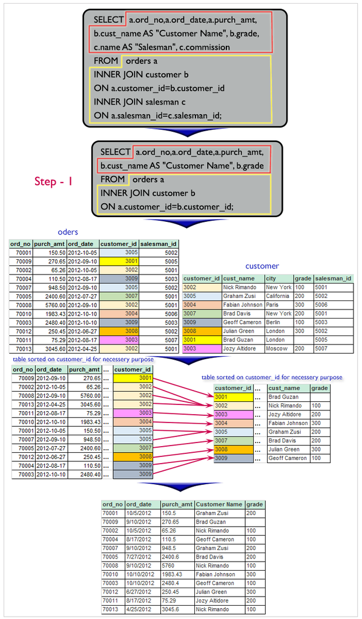

[figure not shown]

7. Write a SQL statement to join the tables salesman, customer and orders so that the same column of each table appears once and only the relational rows are returned. (orders, customer, salesman)

```r
dbGetQuery(mydb,
'SELECT *
FROM orders
NATURAL JOIN customer
NATURAL JOIN salesman;
')
```

| ord_no | purch_amt | ord_date | customer_id | salesman_id | cust_name | city | grade | name | commission |
| --- | --- | --- | --- | --- | --- | --- | --- | --- | --- |
| 70009 | 270.65 | 1347235200 | 3001 | 5005 | Brad Guzan | London | NA | Pit Alex | 0.11 |
| 70002 | 65.26 | 1349395200 | 3002 | 5001 | Nick Rimando | New York | 100 | James Hoog | 0.15 |
| 70005 | 2400.60 | 1343347200 | 3007 | 5001 | Brad Davis | New York | 200 | James Hoog | 0.15 |
| 70008 | 5760.00 | 1347235200 | 3002 | 5001 | Nick Rimando | New York | 100 | James Hoog | 0.15 |
| 70010 | 1983.43 | 1349827200 | 3004 | 5006 | Fabian Johnson | Paris | 300 | Mc Lyon | 0.14 |
| 70013 | 3045.60 | 1335312000 | 3002 | 5001 | Nick Rimando | New York | 100 | James Hoog | 0.15 |

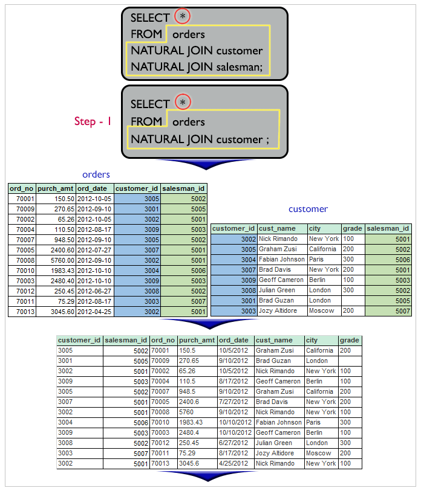

[figure not shown]

8. From the following tables write a SQL query to display the customer name, customer city, grade, salesman, salesman city. The results should be sorted by ascending customer_id. (customer, salesman)

```r
dbGetQuery(mydb,
'SELECT a.cust_name,a.city,a.grade,
b.name AS "Salesman",b.city
FROM customer a
LEFT JOIN salesman b
ON a.salesman_id=b.salesman_id
order by a.customer_id;
')
```

| cust_name | city | grade | Salesman | city |
| --- | --- | --- | --- | --- |
| Brad Guzan | London | NA | Pit Alex | London |
| Nick Rimando | New York | 100 | James Hoog | New York |
| Jozy Altidor | Moscow | 200 | Paul Adam | Rome |
| Fabian Johnson | Paris | 300 | Mc Lyon | Paris |
| Graham Zusi | California | 200 | Nail Knite | Paris |
| Brad Davis | New York | 200 | James Hoog | New York |
| Julian Green | London | 300 | Nail Knite | Paris |
| Geoff Cameron | Berlin | 100 | Lauson Hen | San Jose |

[figure not shown]

ejer8

9. From the following tables write a SQL query to find those customers with a grade less than 300. Return cust_name, customer city, grade, Salesman, salesmancity. The result should be ordered by ascending customer_id. (customer, salesman)

```r
dbGetQuery(mydb,
'SELECT a.cust_name,a.city,a.grade,
b.name AS "Salesman", b.city
FROM customer a
LEFT OUTER JOIN salesman b
ON a.salesman_id=b.salesman_id
WHERE a.grade<300
ORDER BY a.customer_id;
')
```

| cust_name | city | grade | Salesman | city |
| --- | --- | --- | --- | --- |
| Nick Rimando | New York | 100 | James Hoog | New York |
| Jozy Altidor | Moscow | 200 | Paul Adam | Rome |
| Graham Zusi | California | 200 | Nail Knite | Paris |
| Brad Davis | New York | 200 | James Hoog | New York |
| Geoff Cameron | Berlin | 100 | Lauson Hen | San Jose |

[figure not shown]

ejer9

10. Write a SQL statement to make a report with customer name, city, order number, order date, and order amount in ascending order according to the order date to determine whether any of the existing customers have placed an order or not. (orders, customer)

```r
dbGetQuery(mydb,
'SELECT a.cust_name,a.city, b.ord_no,
b.ord_date,b.purch_amt AS "Order Amount"
FROM customer a
LEFT OUTER JOIN orders b
ON a.customer_id=b.customer_id
order by b.ord_date;
')
```

| cust_name | city | ord_no | ord_date | Order Amount |
| --- | --- | --- | --- | --- |
| Nick Rimando | New York | 70013 | 1335312000 | 3045.60 |
| Julian Green | London | 70012 | 1340755200 | 250.45 |
| Brad Davis | New York | 70005 | 1343347200 | 2400.60 |
| Geoff Cameron | Berlin | 70004 | 1345161600 | 110.50 |
| Jozy Altidor | Moscow | 70011 | 1345161600 | 75.29 |
| Nick Rimando | New York | 70008 | 1347235200 | 5760.00 |
| Graham Zusi | California | 70007 | 1347235200 | 948.50 |
| Brad Guzan | London | 70009 | 1347235200 | 270.65 |
| Nick Rimando | New York | 70002 | 1349395200 | 65.26 |
| Graham Zusi | California | 70001 | 1349395200 | 150.50 |

[output cut: 2 more lines]

[figure not shown]

ejer 10

11. SQL statement to generate a report with customer name, city, order number, order date, order amount, salesperson name, and commission to determine if any of the existing customers have not placed orders or if they have placed orders through their salesman or by themselves. (customer, orders, salesman)

```r
dbGetQuery(mydb,
'SELECT a.cust_name,a.city, b.ord_no,
b.ord_date,b.purch_amt AS "Order Amount",
c.name,c.commission
FROM customer a
LEFT OUTER JOIN orders b
ON a.customer_id=b.customer_id
LEFT OUTER JOIN salesman c
ON c.salesman_id=b.salesman_id;
')
```

| cust_name | city | ord_no | ord_date | Order Amount | name | commission |
| --- | --- | --- | --- | --- | --- | --- |
| Nick Rimando | New York | 70002 | 1349395200 | 65.26 | James Hoog | 0.15 |
| Nick Rimando | New York | 70008 | 1347235200 | 5760.00 | James Hoog | 0.15 |
| Nick Rimando | New York | 70013 | 1335312000 | 3045.60 | James Hoog | 0.15 |
| Brad Davis | New York | 70005 | 1343347200 | 2400.60 | James Hoog | 0.15 |
| Graham Zusi | California | 70001 | 1349395200 | 150.50 | Nail Knite | 0.13 |
| Graham Zusi | California | 70007 | 1347235200 | 948.50 | Nail Knite | 0.13 |
| Julian Green | London | 70012 | 1340755200 | 250.45 | Nail Knite | 0.13 |
| Fabian Johnson | Paris | 70010 | 1349827200 | 1983.43 | Mc Lyon | 0.14 |
| Geoff Cameron | Berlin | 70003 | 1349827200 | 2480.40 | Lauson Hen | 0.12 |
| Geoff Cameron | Berlin | 70004 | 1345161600 | 110.50 | Lauson Hen | 0.12 |

[output cut: 2 more lines]

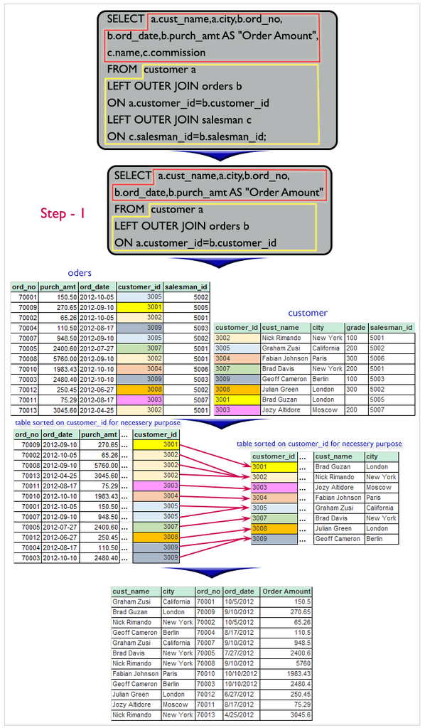

ejer 11-1

[figure not shown]

ejer 11-2

12. Write a SQL statement to generate a list in ascending order of salespersons who work either for one or more customers or have not yet joined any of the customers. (customer, salesman)

```r
dbGetQuery(mydb,
'SELECT a.cust_name,a.city,a.grade,
b.name AS "Salesman", b.city
FROM customer a
RIGHT OUTER JOIN salesman b
ON b.salesman_id=a.salesman_id
ORDER BY b.salesman_id;
')
```

| cust_name | city | grade | Salesman | city |
| --- | --- | --- | --- | --- |
| Nick Rimando | New York | 100 | James Hoog | New York |
| Brad Davis | New York | 200 | James Hoog | New York |
| Graham Zusi | California | 200 | Nail Knite | Paris |
| Julian Green | London | 300 | Nail Knite | Paris |
| Geoff Cameron | Berlin | 100 | Lauson Hen | San Jose |
| Brad Guzan | London | NA | Pit Alex | London |
| Fabian Johnson | Paris | 300 | Mc Lyon | Paris |
| Jozy Altidor | Moscow | 200 | Paul Adam | Rome |

[figure not shown]

ejer 12

13. From the following tables write a SQL query to list all salespersons along with customer name, city, grade, order number, date, and amount. (customer, salesman, orders)

```r
dbGetQuery(mydb,
'SELECT a.cust_name,a.city,a.grade,
b.name AS "Salesman",
c.ord_no, c.ord_date, c.purch_amt
FROM customer a
RIGHT OUTER JOIN salesman b
ON b.salesman_id=a.salesman_id
RIGHT OUTER JOIN orders c
ON c.customer_id=a.customer_id;
')
```

| cust_name | city | grade | Salesman | ord_no | ord_date | purch_amt |
| --- | --- | --- | --- | --- | --- | --- |
| Nick Rimando | New York | 100 | James Hoog | 70002 | 1349395200 | 65.26 |
| Nick Rimando | New York | 100 | James Hoog | 70008 | 1347235200 | 5760.00 |
| Nick Rimando | New York | 100 | James Hoog | 70013 | 1335312000 | 3045.60 |
| Brad Davis | New York | 200 | James Hoog | 70005 | 1343347200 | 2400.60 |
| Graham Zusi | California | 200 | Nail Knite | 70001 | 1349395200 | 150.50 |
| Graham Zusi | California | 200 | Nail Knite | 70007 | 1347235200 | 948.50 |
| Julian Green | London | 300 | Nail Knite | 70012 | 1340755200 | 250.45 |
| Fabian Johnson | Paris | 300 | Mc Lyon | 70010 | 1349827200 | 1983.43 |
| Geoff Cameron | Berlin | 100 | Lauson Hen | 70004 | 1345161600 | 110.50 |
| Geoff Cameron | Berlin | 100 | Lauson Hen | 70003 | 1349827200 | 2480.40 |

[output cut: 2 more lines]

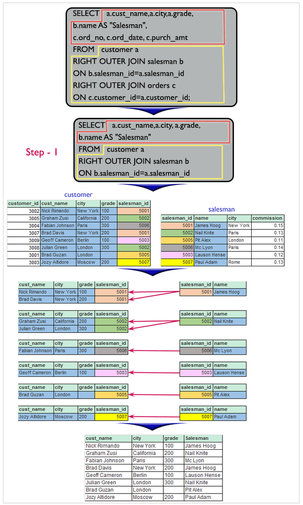

ejer 13-1

[figure not shown]

ejer 13-2

14. Write a SQL statement to make a list for the salesmen who either work for one or more customers or yet to join any of the customer. The customer may have placed, either one or more orders on or above order amount 2000 and must have a grade, or he may not have placed any order to the associated supplier. (customer, salesman, orders)

```r
dbGetQuery(mydb,
'SELECT a.cust_name,a.city,a.grade,
b.name AS "Salesman",
c.ord_no, c.ord_date, c.purch_amt
FROM customer a
RIGHT OUTER JOIN salesman b
ON b.salesman_id=a.salesman_id
LEFT OUTER JOIN orders c
ON c.customer_id=a.customer_id
WHERE c.purch_amt>=2000
AND a.grade IS NOT NULL;
')
```

| cust_name | city | grade | Salesman | ord_no | ord_date | purch_amt |
| --- | --- | --- | --- | --- | --- | --- |
| Nick Rimando | New York | 100 | James Hoog | 70008 | 1347235200 | 5760.0 |
| Nick Rimando | New York | 100 | James Hoog | 70013 | 1335312000 | 3045.6 |
| Brad Davis | New York | 200 | James Hoog | 70005 | 1343347200 | 2400.6 |
| Geoff Cameron | Berlin | 100 | Lauson Hen | 70003 | 1349827200 | 2480.4 |

[figure not shown]

ejer 14-1

[figure not shown]

ejer 14-2

15. For those customers from the existing list who put one or more orders, or which orders have been placed by the customer who is not on the list, create a report containing the customer name, city, order number, order date, and purchase amount. (customer, orders)

```r
dbGetQuery(mydb,
'SELECT a.cust_name,a.city, b.ord_no,
b.ord_date,b.purch_amt AS "Order Amount"
FROM customer a
LEFT OUTER JOIN orders b
ON a.customer_id=b.customer_id;
')
```

| cust_name | city | ord_no | ord_date | Order Amount |
| --- | --- | --- | --- | --- |
| Nick Rimando | New York | 70002 | 1349395200 | 65.26 |
| Nick Rimando | New York | 70008 | 1347235200 | 5760.00 |
| Nick Rimando | New York | 70013 | 1335312000 | 3045.60 |
| Brad Davis | New York | 70005 | 1343347200 | 2400.60 |
| Graham Zusi | California | 70001 | 1349395200 | 150.50 |
| Graham Zusi | California | 70007 | 1347235200 | 948.50 |
| Julian Green | London | 70012 | 1340755200 | 250.45 |
| Fabian Johnson | Paris | 70010 | 1349827200 | 1983.43 |
| Geoff Cameron | Berlin | 70003 | 1349827200 | 2480.40 |
| Geoff Cameron | Berlin | 70004 | 1345161600 | 110.50 |

[output cut: 2 more lines]

[figure not shown]

ejer 15

16. Write a SQL statement to generate a report with the customer name, city, order no. order date, purchase amount for only those customers on the list who must have a grade and placed one or more orders or which order(s) have been placed by the customer who neither is on the list nor has a grade. (customer, orders)

```r
dbGetQuery(mydb,
'SELECT a.cust_name,a.city, b.ord_no,
b.ord_date,b.purch_amt AS "Order Amount"
FROM customer a
FULL OUTER JOIN orders b
ON a.customer_id=b.customer_id
WHERE a.grade IS NOT NULL;
')
```

| cust_name | city | ord_no | ord_date | Order Amount |
| --- | --- | --- | --- | --- |
| Nick Rimando | New York | 70002 | 1349395200 | 65.26 |
| Nick Rimando | New York | 70008 | 1347235200 | 5760.00 |
| Nick Rimando | New York | 70013 | 1335312000 | 3045.60 |
| Brad Davis | New York | 70005 | 1343347200 | 2400.60 |
| Graham Zusi | California | 70001 | 1349395200 | 150.50 |
| Graham Zusi | California | 70007 | 1347235200 | 948.50 |
| Julian Green | London | 70012 | 1340755200 | 250.45 |
| Fabian Johnson | Paris | 70010 | 1349827200 | 1983.43 |
| Geoff Cameron | Berlin | 70004 | 1345161600 | 110.50 |
| Geoff Cameron | Berlin | 70003 | 1349827200 | 2480.40 |

[output cut: 1 more lines]

[figure not shown]

ejer 16

17. Write a SQL query to combine each row of the salesman table with each row of the customer table. (salesman, customer)

```r
dbGetQuery(mydb,
'SELECT *
FROM salesman a
CROSS JOIN customer b;
')
```

| salesman_id | name | city | commission | customer_id | cust_name | city | grade | salesman_id |
| --- | --- | --- | --- | --- | --- | --- | --- | --- |
| 5001 | James Hoog | New York | 0.15 | 3002 | Nick Rimando | New York | 100 | 5001 |
| 5001 | James Hoog | New York | 0.15 | 3007 | Brad Davis | New York | 200 | 5001 |
| 5001 | James Hoog | New York | 0.15 | 3005 | Graham Zusi | California | 200 | 5002 |
| 5001 | James Hoog | New York | 0.15 | 3008 | Julian Green | London | 300 | 5002 |
| 5001 | James Hoog | New York | 0.15 | 3004 | Fabian Johnson | Paris | 300 | 5006 |
| 5001 | James Hoog | New York | 0.15 | 3009 | Geoff Cameron | Berlin | 100 | 5003 |
| 5001 | James Hoog | New York | 0.15 | 3003 | Jozy Altidor | Moscow | 200 | 5007 |
| 5001 | James Hoog | New York | 0.15 | 3001 | Brad Guzan | London | NA | 5005 |
| 5002 | Nail Knite | Paris | 0.13 | 3002 | Nick Rimando | New York | 100 | 5001 |
| 5002 | Nail Knite | Paris | 0.13 | 3007 | Brad Davis | New York | 200 | 5001 |

[output cut: 38 more lines]

[figure not shown]

ejer 17

18. Write a SQL statement to create a Cartesian product between salesperson and customer, i.e. each salesperson will appear for all customers and vice versa for that salesperson who belongs to that city. (salesman, customer)

```r
dbGetQuery(mydb,
'SELECT *
FROM salesman a
CROSS JOIN customer b
WHERE a.city IS NOT NULL;
')
```

[output not shown]

[figure not shown]

ejer 18

```r
dbDisconnect(mydb)
```